# 5. Data Structures for Analysis: Pandas

# 5.1 Introduction to Pandas

1. Pandas sees wide range of application in diverse fields of research in academics and industry
2. Fast and efficient DataFrame object with default and customized indexing.
3. Tools for loading data into in-memory data objects from different file formats.
4. Integrated handling of missing data.
5. Many data manipulation and cleaning functions
   - Label-based slicing, indexing and sub setting of large data sets.
   - Columns from a data structure can be deleted or inserted.
   - Group by data for aggregation and transformations.
   - High performance merging and joining of data.

   > **Pandas DataFrame is two-dimensional size-mutable, potentially heterogeneous tabular data structure with labeled axes (rows and columns). A Data frame is a two-dimensional data structure, i.e., data is aligned in a tabular fashion in rows and columns. Pandas DataFrame consists of three principal components, the data, rows, and columns.**

You will be required to import pandas as ‘pd’ and then use ‘pd’ object to perform other basic pandas operations.

```python
import pandas as pd
import numpy as np
print('pandas', pd.__version__)
print('numpy', np.__version__)
```

```
pandas 1.1.5
numpy 1.19.5
```

# 5.2 Reading Data into Pandas

## 5.2.1 Data Files

- The Pandas library save data to files and load data from files. Different File types are:
  - CSV and Excel files
  - JSON
  - Web pages
  - Databases
  - Python pickle files
- A CSV (comma-separated values) file is a text file that has a specific format which allows data to be saved in a table structured format

Some more information [here](https://realpython.com/pandas-read-write-files/)

## 5.2.2 Dictionaries to Dataframe

Typically used in intermediate stage data processing and conversion to pandas data frame

```python
#Create a Dictionary of series
data = {'Name':['Wood', 'Winston', 'Williams', 'White', 'Lorenzen'],
   'Weight':[255,231,195,185,285],
   'No':[49,2,43,14, 13],
   'Pos':['LS', 'QB', 'FS', 'WR', 'QB']}
```

```python
df1 = pd.DataFrame(data)
print(df1)
```

```
       Name  Weight  No Pos
0      Wood     255  49  LS
1   Winston     231   2  QB
2  Williams     195  43  FS
3     White     185  14  WR
4  Lorenzen     285  13  QB
```

## 5.2.3 Side Note on `Gitgub Raw`

- In rest of the course we shall use data stored in Github as a `raw` file
- The `raw.githubusercontent.com` domain is used to serve unprocessed versions of files stored in GitHub repositories.
- Browse to a file on `GitHub` and then click the`Raw link` to get the `raw` file

## 5.2.4 Read CSVs

- Most popular way of reading data into pandas data frame
- Can handle pretty large data file reads. Here is a [article](https://towardsdatascience.com/why-and-how-to-use-pandas-with-large-data-9594dda2ea4c).

```python
# import pandas as pd
download_url = "https://raw.githubusercontent.com/sdhar-pycourse/py-datascience-biz/main/practise-datasets/bivar.csv"
df2 = pd.read_csv(download_url)
```

```python
for df in [df1, df2]:
  print('Object Type:', type(df), df.size, 'in kb')
  # /1024*1024
```

```
Object Type: <class 'pandas.core.frame.DataFrame'> 20 in kb
Object Type: <class 'pandas.core.frame.DataFrame'> 546 in kb
```

## 5.2.5 Export to CSV

```python
from google.colab import files
df2.to_csv('filename.csv')
files.download('filename.csv')
```

## 5.2.6 Pandas `.set_options()`

Pandas supports environmental setting for easy browsing of data

```python
#configure Pandas to display all columns
pd.set_option("display.max.columns", None)
print('Max Num of Cols:', pd.options.display.max_columns)
# Change precision to 2.
pd.set_option('display.precision', 2)
print('float precision:', pd.options.display.precision)
```

```
Max Num of Cols: None
float precision: 2
```

## 5.2.7. Understanding PAndas Data Structure

- `pd.DataFrames` are the large scale data structures in Pandas
- Each DataFrame can be broken into `pd.Series`
- Each series is like a list that is built on a numpy array
- The data manipulation capabilities of pandas are built on top of the numpy library.
  - Numpy is a dependency of the pandas library.
- Pandas is best at handling tabular data sets comprising different variable types (integer, float, double, etc.) and loading data
- Pandas has libraries for feature engineering, handling time series data and pipeling data
- Numpy is most suitable for scientific computations

```python
type(df2.x4)
```

```
pandas.core.series.Series
```

```python
print('Decompising main Pandas Data Structure:')
print()
print('Data Structure:  ', type(df2))
print('Series: ', type(df2['x2']), type(df2.x4))
print('Index: ', type(df2.index))
print('Underlying NumPy array in Series:', type(df2.x2.values))
print('Underlying NumPy array in Index: ', type(df2.index.values))
```

```
Decompising main Pandas Data Structure:

Data Structure:   <class 'pandas.core.frame.DataFrame'>
Series:  <class 'pandas.core.series.Series'> <class 'pandas.core.series.Series'>
Index:  <class 'pandas.core.indexes.range.RangeIndex'>
Underlying NumPy array in Series: <class 'numpy.ndarray'>
Underlying NumPy array in Index:  <class 'numpy.ndarray'>
```

# 5.3 Basic info on Data

## 5.3.1 `.shape()` et al

Pandas `.size`, `.shape` and `.ndim` are used to return size, shape and dimensions of data frames and series

```python
print(df2.shape)
```

```
(78, 7)
```

```python
df2.size
```

```
546
```

```python
df2.ndim
```

```
2
```

## 5.3.2 `.head()`

Pandas `head()` method is used to return `top n` (5 by default) rows of a data frame or series.

```python
print(df2.head()) # if no value given it will print first 5 rows
```

```
   idx  x3  x2  x1  y2  y1  x4
0    1   1   4   3   1   1   4
1    2   0   2   3   0   1   3
2    3   0   1   3   1   0   2
3    4   1   1   3   1   1   2
4    5   0   1   3   1   1   2
```

```python
print(df2.head(10))
```

```
   idx  x3  x2  x1  y2  y1  x4
0    1   1   4   3   1   1   4
1    2   0   2   3   0   1   3
2    3   0   1   3   1   0   2
3    4   1   1   3   1   1   2
4    5   0   1   3   1   1   2
5    6   0   1   3   0   1   2
6    7   1   2   2   0   1   2
7    8   0   1   3   0   0   2
8    9   0   2   1   0   0   1
9   10   1   2   3   1   1   2
```

## 5.3.3 `.tail()`

Pandas `tail()` method is used to return `bottom n` (5 by default) rows of a data frame or series.

```python
print(df.tail())
```

```
    idx  x3  x2  x1  y2  y1  x4
73   74   0   2   1   0   0   1
74   75   0   1   3   0   1   2
75   76   0   4   3   1   0   2
76   77   0   1   2   0   0   1
77   78   1   3   1   1   1   2
```

```python
df.tail(10)
```

|  | idx | x3 | x2 | x1 | y2 | y1 | x4 |
| --- | --- | --- | --- | --- | --- | --- | --- |
| 68 | 69 | 0 | 1 | 2 | 1 | 0 | 2 |
| 69 | 70 | 0 | 3 | 1 | 1 | 1 | 2 |
| 70 | 71 | 0 | 2 | 3 | 0 | 1 | 3 |
| 71 | 72 | 0 | 2 | 2 | 0 | 0 | 1 |
| 72 | 73 | 1 | 3 | 1 | 1 | 1 | 2 |
| 73 | 74 | 0 | 2 | 1 | 0 | 0 | 1 |
| 74 | 75 | 0 | 1 | 3 | 0 | 1 | 2 |
| 75 | 76 | 0 | 4 | 3 | 1 | 0 | 2 |
| 76 | 77 | 0 | 1 | 2 | 0 | 0 | 1 |
| 77 | 78 | 1 | 3 | 1 | 1 | 1 | 2 |

## 5.3.4 `.describe()`

- Generate descriptive statistics for numerical variables
- Descriptive statistics include those that summarize the mean, median and quartiles

```python
print(df2.describe())
print()
print(type(df2.describe()))
```

```
         idx     x3     x2     x1     y2     y1     x4
count  78.00  78.00  78.00  78.00  78.00  78.00  78.00
mean   39.50   0.10   1.81   2.14   0.37   0.54   1.81
std    22.66   0.31   0.97   0.75   0.49   0.50   0.79
min     1.00   0.00   1.00   1.00   0.00   0.00   1.00
25%    20.25   0.00   1.00   2.00   0.00   0.00   1.00
50%    39.50   0.00   1.00   2.00   0.00   1.00   2.00
75%    58.75   0.00   2.75   3.00   1.00   1.00   2.00
max    78.00   1.00   4.00   3.00   1.00   1.00   4.00

<class 'pandas.core.frame.DataFrame'>
```

```python
df1.describe(include= 'all')
```

|  | Name | Weight | No | Pos |
| --- | --- | --- | --- | --- |
| count | 5 | 5.00 | 5.00 | 5 |
| unique | 5 | NaN | NaN | 4 |
| top | Lorenzen | NaN | NaN | QB |
| freq | 1 | NaN | NaN | 2 |
| mean | NaN | 230.20 | 24.20 | NaN |
| std | NaN | 41.54 | 20.56 | NaN |
| min | NaN | 185.00 | 2.00 | NaN |
| 25% | NaN | 195.00 | 13.00 | NaN |
| 50% | NaN | 231.00 | 14.00 | NaN |
| 75% | NaN | 255.00 | 43.00 | NaN |
| max | NaN | 285.00 | 49.00 | NaN |

## 5.3.5 `.value_counts()`

Return a Series containing counts of unique values.

The resulting object will be in descending order so that the first element is the most frequently-occurring element. Excludes NA values by default.

```python
df2.y2.value_counts()
```

```
0    49
1    29
Name: y2, dtype: int64
```

```python
df1.Pos.value_counts(sort=False)
```

```
QB    2
LS    1
WR    1
FS    1
Name: Pos, dtype: int64
```

```python
print(type(df1.Pos.value_counts(sort=False)))
print(df1.Pos.value_counts(sort=False).index.values)
```

```
<class 'pandas.core.series.Series'>
['QB' 'LS' 'WR' 'FS']
```

## 5.3.6 `.info()`

Prints a concise summary of a DataFrame.

This method prints information about a DataFrame including the index dtype and columns, non-null values and memory usage.

```python
df2.info()
```

```
<class 'pandas.core.frame.DataFrame'>
RangeIndex: 78 entries, 0 to 77
Data columns (total 7 columns):
 #   Column  Non-Null Count  Dtype
---  ------  --------------  -----
 0   idx     78 non-null     int64
 1   x3      78 non-null     int64
 2   x2      78 non-null     int64
 3   x1      78 non-null     int64
 4   y2      78 non-null     int64
 5   y1      78 non-null     int64
 6   x4      78 non-null     int64
dtypes: int64(7)
memory usage: 4.4 KB
```

## 5.3.6 `.dtypes()`

- Return the dtypes in the DataFrame.
- This returns a `Series` with the data type of each column.
- The result’s index is the original DataFrame’s columns. Columns with mixed types are stored with the object dtype.

```python
df1.dtypes
```

```
Name      object
Weight     int64
No         int64
Pos       object
dtype: object
```

# 5.4 Pandas DataFrame indexes/ columns

## 5.4.1 set/ reset `index`

Indexes are Immutable sequence used for indexing and alignment. The basic object storing axis labels for all pandas objects.

- The axis labeling information in pandas objects serves many purposes:
- Identifies data (i.e. provides metadata) using known indicators, important for analysis, visualization, and interactive console display.
  - Enables automatic and explicit data alignment.
  - Allows intuitive getting and setting of subsets of the data set.

In this section, we will focus on the final point: namely, how to slice, dice, and generally get and set subsets of pandas objects. The primary focus will be on Series and DataFrame as they have received more development attention in this area.

```python
print(df1)
print()
df1 = pd.DataFrame(data, index=['a', 'b', 'c', 'd', 'e'])
print(df1)
```

```
       Name  Weight  No Pos
0      Wood     255  49  LS
1   Winston     231   2  QB
2  Williams     195  43  FS
3     White     185  14  WR
4  Lorenzen     285  13  QB

       Name  Weight  No Pos
a      Wood     255  49  LS
b   Winston     231   2  QB
c  Williams     195  43  FS
d     White     185  14  WR
e  Lorenzen     285  13  QB
```

`DataFrame.reset_index(level=None, drop=False, inplace=False, col_level=0, col_fill='')`

Reset the index, or a level of it.

Reset the index of the DataFrame, and use the default one instead. If the DataFrame has a MultiIndex, this method can remove one or more levels.

MultiIndex- Will keep put of scope for now. If you are interested you can look [here](https://www.datacamp.com/community/tutorials/pandas-multi-index)

```python
df1.reset_index() # this won't make any change in df1
print(df1)
```

```
       Name  Weight  No Pos
a      Wood     255  49  LS
b   Winston     231   2  QB
c  Williams     195  43  FS
d     White     185  14  WR
e  Lorenzen     285  13  QB
```

```python
df1.reset_index(drop = True,inplace=True)
print(df1)
```

```
       Name  Weight  No Pos
0      Wood     255  49  LS
1   Winston     231   2  QB
2  Williams     195  43  FS
3     White     185  14  WR
4  Lorenzen     285  13  QB
```

## 5.4.2 `.drop`

`DataFrame.drop(labels=None, axis=0, index=None, columns=None, level=None, inplace=False, errors='raise')`

Drop specified labels from rows or columns.

Remove rows or columns by specifying label names and corresponding axis, or by specifying directly index or column names. When using a multi-index, labels on different levels can be removed by specifying the level.

```python
df3= df1.copy(deep=True)
df3
```

[output not shown]

Dropping one row

```python
df3.drop('c', axis=0)
```

|  | Name | Weight | No | Pos |
| --- | --- | --- | --- | --- |
| a | Wood | 255 | 49 | LS |
| b | Winston | 231 | 2 | QB |
| d | White | 185 | 14 | WR |
| e | Lorenzen | 285 | 13 | QB |

Dropping more than one row

```python
df3.drop(['a','d'])
```

|  | Name | Weight | No | Pos |
| --- | --- | --- | --- | --- |
| b | Winston | 231 | 2 | QB |
| c | Williams | 195 | 43 | FS |
| e | Lorenzen | 285 | 13 | QB |

```python
df3.drop('Name',axis = 1) # axis = 1 is for columns
```

|  | Weight | No | Pos |
| --- | --- | --- | --- |
| a | 255 | 49 | LS |
| b | 231 | 2 | QB |
| c | 195 | 43 | FS |
| d | 185 | 14 | WR |
| e | 285 | 13 | QB |

Above code can also be written as

```python
df3.drop('Name',axis = 'columns')
```

|  | Weight | No | Pos |
| --- | --- | --- | --- |
| a | 255 | 49 | LS |
| b | 231 | 2 | QB |
| c | 195 | 43 | FS |
| d | 185 | 14 | WR |
| e | 285 | 13 | QB |

Dropping More than one columns

```python
df3.drop(['Name','No'],axis = 1)
```

|  | Weight | Pos |
| --- | --- | --- |
| a | 255 | LS |
| b | 231 | QB |
| c | 195 | FS |
| d | 185 | WR |
| e | 285 | QB |

drop has a default setting as `inplace= False`. This basically means that it drops the columns/ index when creating a output with the command but leaves the object in the memory without any change.

This can be manipulated by toggling to `inplace= True`

```python
df3.drop('Name',axis = 'columns',inplace=True)
print(df3)
```

```
   Weight  No Pos
a     255  49  LS
b     231   2  QB
c     195  43  FS
d     185  14  WR
e     285  13  QB
```

```python
df3.columns
```

```
Index(['Weight', 'No', 'Pos'], dtype='object')
```

## 5.4.2 `rename`

`DataFrame.rename(mapper=None, index=None, columns=None, axis=None, copy=True, inplace=False, level=None, errors='ignore')`

Alter axes labels.

Function / dict values must be unique (1-to-1).

Labels not contained in a dict / Series will be left as-is. Extra labels listed don’t throw an error.

```python
df1
```

[output not shown]

```python
df1.columns
```

```
Index(['Name', 'Weight', 'No', 'Pos'], dtype='object')
```

```python
df3 = df3.rename(columns={'No':'Number', 'Pos': 'Position'})
print(df3)
```

```
   Weight  Number Position
a     255      49       LS
b     231       2       QB
c     195      43       FS
d     185      14       WR
e     285      13       QB
```

## 5.4.3 `.sort_values()`

`DataFrame.sort_values(by, axis=0, ascending=True, inplace=False, kind='quicksort', na_position='last', ignore_index=False, key=None)`

Sort by the values along either axis 0 or 1

```python
df3
```

|  | Weight | Number | Position |
| --- | --- | --- | --- |
| a | 255 | 49 | LS |
| b | 231 | 2 | QB |
| c | 195 | 43 | FS |
| d | 185 | 14 | WR |
| e | 285 | 13 | QB |

```python
df3.sort_values(by='Weight', ascending=False).head(5)
```

|  | Weight | Number | Position |
| --- | --- | --- | --- |
| e | 285 | 13 | QB |
| a | 255 | 49 | LS |
| b | 231 | 2 | QB |
| c | 195 | 43 | FS |
| d | 185 | 14 | WR |

```python
df3.sort_values(by=['Position', 'Weight'])
```

|  | Weight | Number | Position |
| --- | --- | --- | --- |
| c | 195 | 43 | FS |
| a | 255 | 49 | LS |
| b | 231 | 2 | QB |
| e | 285 | 13 | QB |
| d | 185 | 14 | WR |

```python
df3.sort_values(by=['Position', 'Weight'],ascending= False)
```

|  | Weight | Number | Position |
| --- | --- | --- | --- |
| d | 185 | 14 | WR |
| e | 285 | 13 | QB |
| b | 231 | 2 | QB |
| a | 255 | 49 | LS |
| c | 195 | 43 | FS |

# 5.5 Querying Pandas Objects

Querying requires the following to happen:

- Access subsets of a huge dataset based on its indices
- Select rows based on the values in your dataset’s columns

## 5.5.1 Subset using `.loc` and `.iloc`

The main distinction between the two methods is:

- `.loc()` gets rows (and/or columns) with particular **labels**.
- `.iloc()` gets rows (and/or columns) at integer **locations**.

```python
df2
```

|  | idx | x3 | x2 | x1 | y2 | y1 | x4 |
| --- | --- | --- | --- | --- | --- | --- | --- |
| 0 | 1 | 1 | 4 | 3 | 1 | 1 | 4 |
| 1 | 2 | 0 | 2 | 3 | 0 | 1 | 3 |
| 2 | 3 | 0 | 1 | 3 | 1 | 0 | 2 |
| 3 | 4 | 1 | 1 | 3 | 1 | 1 | 2 |
| 4 | 5 | 0 | 1 | 3 | 1 | 1 | 2 |
| ... | ... | ... | ... | ... | ... | ... | ... |
| 73 | 74 | 0 | 2 | 1 | 0 | 0 | 1 |
| 74 | 75 | 0 | 1 | 3 | 0 | 1 | 2 |
| 75 | 76 | 0 | 4 | 3 | 1 | 0 | 2 |
| 76 | 77 | 0 | 1 | 2 | 0 | 0 | 1 |
| 77 | 78 | 1 | 3 | 1 | 1 | 1 | 2 |

78 rows × 7 columns

```python
df2.loc[4]
```

```
idx    5
x3     0
x2     1
x1     3
y2     1
y1     1
x4     2
Name: 4, dtype: int64
```

```python
df2.loc[2:10:2,['idx', 'y2', 'x4']]
```

|  | idx | y2 | x4 |
| --- | --- | --- | --- |
| 2 | 3 | 1 | 2 |
| 4 | 5 | 1 | 2 |
| 6 | 7 | 0 | 2 |
| 8 | 9 | 0 | 1 |
| 10 | 11 | 0 | 1 |

```python
df2.loc[4,['x4', 'y1']]
```

```
x4    2
y1    1
Name: 4, dtype: int64
```

```python
df2.iloc[0:2,0:6:2]
```

|  | idx | x2 | y2 |
| --- | --- | --- | --- |
| 0 | 1 | 4 | 1 |
| 1 | 2 | 2 | 0 |

```python
df2.iloc[4, [6,5]]
```

```
x4    2
y1    1
Name: 4, dtype: int64
```

```python
df2.iloc[4, 3:6]
```

```
x1    3
y2    1
y1    1
Name: 4, dtype: int64
```

```python
df2.iloc[4, 3:6:2]
```

```
x1    3
y1    1
Name: 4, dtype: int64
```

## 5.5.2 Boolean Indexing

```python
df1
```

[output not shown]

```python
df1.loc[df1.Name == 'Williams']
```

|  | Name | Weight | No | Pos |
| --- | --- | --- | --- | --- |
| 2 | Williams | 195 | 43 | FS |

```python
df1.loc[(df1.Pos.isin(['LS', 'QB'])) & (df1.Weight> 215)]
```

|  | Name | Weight | No | Pos |
| --- | --- | --- | --- | --- |
| 0 | Wood | 255 | 49 | LS |
| 1 | Winston | 231 | 2 | QB |
| 4 | Lorenzen | 285 | 13 | QB |

```python
df2.loc[0]
```

```
idx    1
x3     1
x2     4
x1     3
y2     1
y1     1
x4     4
Name: 0, dtype: int64
```

```python
df2.loc[(df2.y1==1) & (df2.x2 >= 2),'x4']
```

```
0     4
1     3
6     2
9     2
12    2
13    4
14    3
16    2
25    2
29    3
34    2
35    1
39    2
40    2
43    2
56    2
57    2
58    2
59    3
62    3
64    2
66    3
69    2
70    3
72    2
77    2
Name: x4, dtype: int64
```

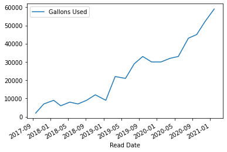

```python
pd.read_excel('water readings.xls').plot('Read Date', 'Gallons Used')
```